# Лабораторная работа №8

Планировщики событий

Хохлачева Полина Дмитриевна

Российский университет дружбы народов, Москва, Россия

# Информация

## Докладчик

- Хохлачева Полина Дмитриевна
- Российский университет дружбы народов
- Номер студенческого билета- 1132242473
- [1132242473@pfur.ru]

# Вводная часть

## Цель работы

Получение навыков работы с планировщиками событий cron и at.

# Выполнение лабораторной работы

Получаем полномочия администратора, просматриваем статус демона crond -l и просматриваем содержимое файла конфигурации(рис. [-@fig:001]).

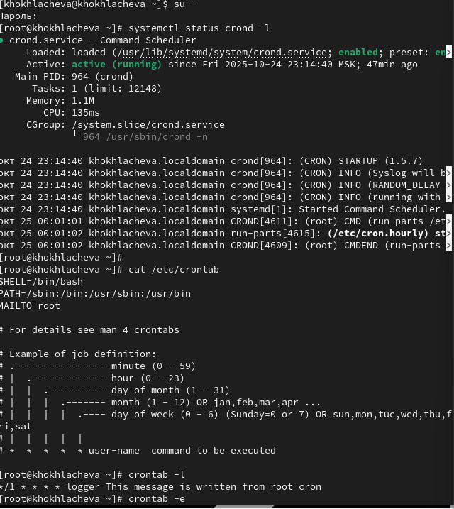

Просмотр

## Выполнение лабораторной работы

Просматриваем список заданий и файл расписания на редактирование, также открываем файл для редактирования (рис. [-@fig:002]).

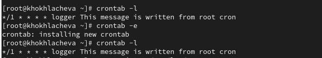

Редактирование

## Выполнение лабораторной работы

Добавляем следующую строку в файл(рис. [-@fig:003]).

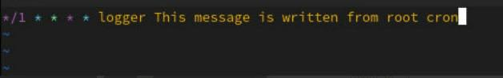

Добавление

## Выполнение лабораторной работы

Не выключая систему просматриваем журнал(рис. [-@fig:004]).

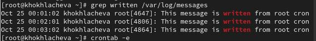

Просмотр

## Выполнение лабораторной работы

Изменяем запись в расписании(рис. [-@fig:005]).

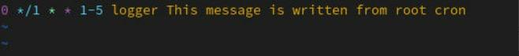

Изменение

## Выполнение лабораторной работы

Переходим в каталог, создаём в нём файл сценария и прописываем в нём следующий скрипт(рис. [-@fig:006]).

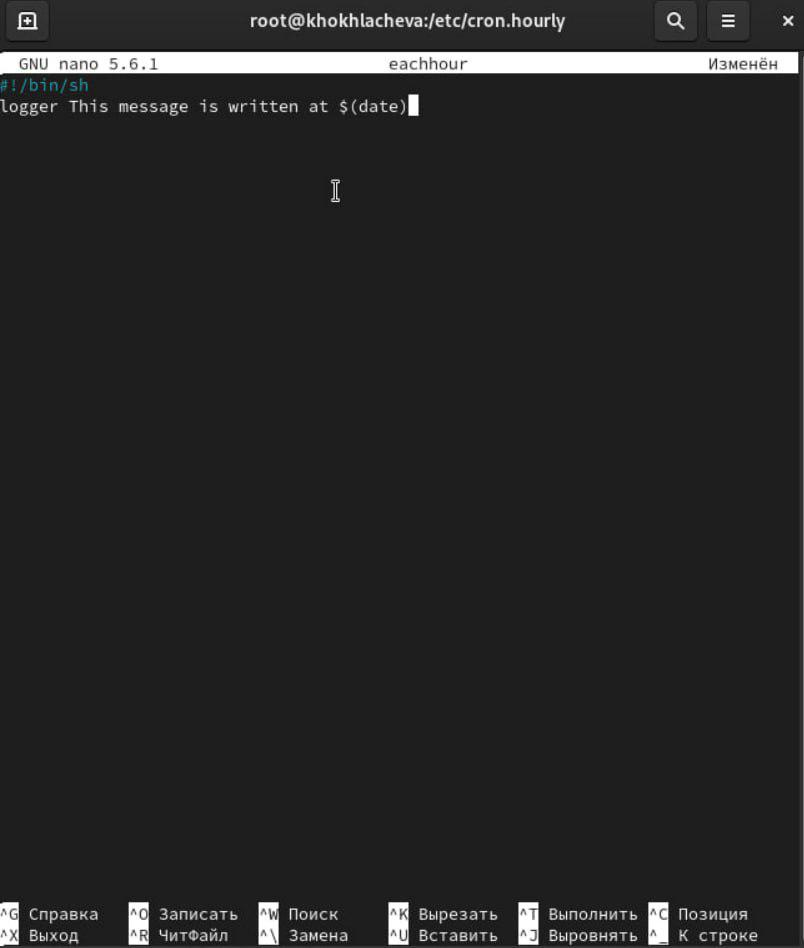

Прописание скрипта

## Выполнение лабораторной работы

Перейдя в каталог, создав в нём файл с расписанием, поместили в него нужное содержимое, не выключая систему через некоторое время (2-3 часа), просмотрели журнал системы событий(рис. [-@fig:007]).

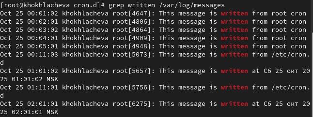

Создание расписания

## Выполнение лабораторной работы

Получаем полномочия администратора, проверяем, что служба atd загружена и включена(рис. [-@fig:008]).

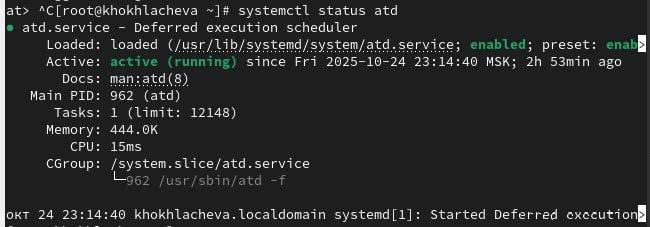

Проверка службы

## Выполнение лабораторной работы

Планируем действие, убеждаемся, что оно запланировано и с помощью команды убеждаемся, что появилось соответствующее сообщение в указанное время(рис. [-@fig:009]).

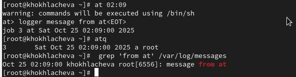

Сообщение в указанное время

# Выводы

Мы получили навыки работы с планировщиками событий cron и at.